# 03_descriptive_EDA

2026-10-22

# Stage 3: Descriptive Statistics and Exploratory Data Analysis

This R Markdown notebook extracts the **executable R code** from the supplied Stage 3 tutorial and arranges it like the Stage 2 data-cleaning notebook. It covers Steps **18–22** for adult travellers in the 2022 NextGen NHTS. All code comments and output labels are in English.

**Input:** `data/processed/analysis_data.rds` produced by Stage 2. **Outputs:** CSV summaries in `tables/` and 300-DPI PNG figures in `figures/`. The notebook detects whether it is executed from the project root or from the `R/` subdirectory to avoid path errors when switching between RStudio and VSCode.

**Scope:** The main comparisons are descriptive and unweighted; they cannot establish statistical significance or a causal effect of population density. The optional weighted mean block does not account for survey-design variance. The expected group counts embedded below are reference checkpoints, not results verified in this file.

## Data loading and pre-analysis validation

### Load packages and the Stage 2 dataset

```r
# ==================================================
# Load packages and the Stage 2 dataset
# ==================================================
# library(tidyverse) loads readr, dplyr, tidyr and ggplot2 for this stage.
# Find the project root by testing both possible working directories:
# RStudio often knits from R/, whereas VSCode may run from the project root.
# readRDS() restores the cleaned person-level data created in Stage 2.
# Each row should represent an individual adult traveller, not an individual trip.
# dim(), glimpse(), nrow(), n_distinct() and anyDuplicated() provide initial checks.

# Load the Tidyverse tools used throughout the stage.
library(tidyverse)
# First check whether the working directory is R/; otherwise check the root.
# Stop with a useful message if neither location contains the Stage 2 output.
if (file.exists("../data/processed/analysis_data.rds")) {
  project_root <- ".."
} else if (file.exists("data/processed/analysis_data.rds")) {
  project_root <- "."
} else {
  stop("Cannot find data/processed/analysis_data.rds. Check the working directory and Stage 2 output.")
}

# Construct paths with file.path() so they work on Windows and macOS.
input_file <- file.path(project_root, "data", "processed", "analysis_data.rds")
figures_dir <- file.path(project_root, "figures")
tables_dir <- file.path(project_root, "tables")

# Create output folders once; existing folders are left unchanged.
dir.create(figures_dir, showWarnings = FALSE, recursive = TRUE)
dir.create(tables_dir, showWarnings = FALSE, recursive = TRUE)

# Restore Stage 2's cleaned person-level records and inspect their structure.
analysis_data <- readRDS(input_file)
cat("Project root:", normalizePath(project_root), "\n")
```

```
## Project root: I:\URBAN5127 - Quantitative Data Analysis\URBAN5127_NHTS
```

```r
cat("Input dataset:", normalizePath(input_file), "\n")
```

```
## Input dataset: I:\URBAN5127 - Quantitative Data Analysis\URBAN5127_NHTS\data\processed\analysis_data.rds
```

```r
# Inspect number of rows and variables.
dim(analysis_data)
```

```
## [1] 9052  170
```

```r
glimpse(analysis_data)
```

```
## Rows: 9,052
## Columns: 170
## $ HOUSEID             <chr> "9000013002", "9000013002", "9000013016", "9000013…
## $ PERSONID            <chr> "01", "02", "01", "02", "01", "01", "02", "01", "0…
## $ WTPERFIN            <chr> "3938.688806", "5409.5145725", "3183.4208104", "32…
## $ WTPERFIN5D          <chr> "0", "0", "4177.2344524", "4010.8099954", "12540.6…
## $ WTPERFIN2D          <chr> "13363.8093550292", "19360.0949193166", "0", "0", …
## $ R_AGE               <chr> "39", "42", "32", "41", "38", "59", "38", "73", "2…
## $ R_SEX               <chr> "02", "01", "02", "01", "01", "01", "02", "01", "0…
## $ R_RELAT             <chr> "07", "01", "07", "01", "07", "07", "01", "07", "0…
## $ WORKER              <chr> "02", "01", "01", "01", "01", "01", "01", "02", "0…
## $ DRIVER              <chr> "01", "01", "01", "01", "01", "01", "01", "01", "0…
## $ R_RACE              <chr> "01", "01", "01", "01", "01", "03", "03", "01", "0…
## $ GCDWORK             <chr> "-1", "-9", "4.88245118144333", "-9", "-9", "25.23…
## $ OUTOFTWN            <chr> "02", "02", "02", "02", "02", "02", "02", "02", "0…
```

[output cut: 157 more lines]

```r
# Report sample size, number of households, and duplicate person keys.
cat("Person records:", nrow(analysis_data), "\n")
```

```
## Person records: 9052
```

```r
cat("Distinct households:", n_distinct(analysis_data$HOUSEID), "\n")
```

```
## Distinct households: 6113
```

```r
cat("Duplicate person-key index (expect 0):", anyDuplicated(
  analysis_data[c("HOUSEID", "PERSONID")]
), "\n")
```

```
## Duplicate person-key index (expect 0): 0
```

### Confirm required columns and valid outcome values

```r
# ==================================================
# Confirm required columns and valid outcome values
# ==================================================
# required_vars lists the columns needed for the analyses below.
# %in% checks membership in names(analysis_data); all() requires every name to exist.
# stopifnot() stops knitting if a required field is missing or validation fails.
# is.finite() rules out NA, NaN and infinite distances; zero is allowed.
# This verifies basic integrity but does NOT prove representativeness or causal validity.

# The code below relies on each of these original or recoded variables.
required_vars <- c(
  "HOUSEID",
  "PERSONID",
  "mean_trip_miles",
  "density_band",
  "age",
  "worker",
  "hh_size",
  "vehicles",
  "car_group",
  "day_of_week",
  "person_weight"
)
# Fail early rather than generate misleading summaries when checks are violated.
stopifnot(
  all(required_vars %in% names(analysis_data))
)
stopifnot(
  all(is.finite(analysis_data$mean_trip_miles)),
  all(analysis_data$mean_trip_miles >= 0),
  !anyNA(analysis_data$density_band)
)
```

## Step 18 - Overall descriptive statistics

### Step 18.1 - Describe the dependent variable

```r
# ==================================================
# Step 18.1 - Describe the dependent variable
# ==================================================
# One row per person means n() measures the number of adult travellers.
# n_distinct(HOUSEID) counts unique households represented in the sample.
# mean(), median() and sd() describe central tendency and dispersion.
# quantile() calculates the selected percentiles; the upper percentiles reveal long tails.
# zero_n counts exactly zero person-level means; zero_pct expresses the share in percent.
# These are unweighted descriptive statistics unless explicitly stated otherwise.

# Build the overall dependent-variable descriptive statistics table.
y_summary <- analysis_data %>%
  summarise(
    # Count persons in the cleaned sample.
    n = n(),
    # Count distinct household IDs.
    households = n_distinct(HOUSEID),
    # Arithmetic mean of the personal mean trip distances.
    mean_miles = mean(mean_trip_miles),
    # Median, which is more robust to extreme long-distance observations.
    median_miles = median(mean_trip_miles),
    # Standard deviation measures variation among respondents.
    sd_miles = sd(mean_trip_miles),
    min_miles = min(mean_trip_miles),
    q1_miles = quantile(
      mean_trip_miles, 0.25
    ),
    q3_miles = quantile(
      mean_trip_miles, 0.75
    ),
    p95_miles = quantile(
      mean_trip_miles, 0.95
    ),
    p99_miles = quantile(
      mean_trip_miles, 0.99
    ),
    max_miles = max(mean_trip_miles),
    # Count zero mean-trip-distance records.
    zero_n = sum(mean_trip_miles == 0),
    zero_pct = 100 * mean(
      mean_trip_miles == 0
    )
  )
print(y_summary, width = Inf)
```

```
## # A tibble: 1 × 13
##       n households mean_miles median_miles sd_miles min_miles q1_miles q3_miles
##   <int>      <int>      <dbl>        <dbl>    <dbl>     <dbl>    <dbl>    <dbl>
## 1  9052       6113       18.2         5.57     71.3         0     2.53     12.9
##   p95_miles p99_miles max_miles zero_n zero_pct
##       <dbl>     <dbl>     <dbl>  <int>    <dbl>
## 1      48.5      285.     2436.     49    0.541
```

### Step 18.1 - Additional percentile check

```r
# ==================================================
# Step 18.1 - Additional percentile check
# ==================================================
# probs specifies the percentiles to report as values between zero and one.
# P95 is a threshold below which approximately 95% of observations fall.

quantile(
  analysis_data$mean_trip_miles,
  probs = c(0.25, 0.5, 0.75, 0.95, 0.99)
)
```

```
##        25%        50%        75%        95%        99%
##   2.526336   5.570696  12.863891  48.535534 285.373533
```

### Step 18.2 - Summarise continuous covariates

```r
# ==================================================
# Step 18.2 - Summarise continuous covariates
# ==================================================
# select() keeps the outcome and three numeric covariates for this summary.
# pivot_longer() converts columns into variable/value rows so one group-by works for all.
# group_by(variable) makes summarise() compute separate statistics by variable.
# na.rm = TRUE excludes missing observations from each numeric calculation.
# n here counts non-missing observations; it can differ by variable.

# Produce a compact Table 1-style summary for all four numeric variables.
continuous_summary <- analysis_data %>%
  select(
    mean_trip_miles,
    age,
    hh_size,
    vehicles
  ) %>%
  # Change from wide data to one variable/value pair per row.
  pivot_longer(
    cols = everything(),
    names_to = "variable",
    values_to = "value"
  ) %>%
  group_by(variable) %>%
  summarise(
    n = sum(!is.na(value)),
    mean = mean(value, na.rm = TRUE),
    sd = sd(value, na.rm = TRUE),
    median = median(value, na.rm = TRUE),
    q1 = quantile(
      value, 0.25, na.rm = TRUE
    ),
    q3 = quantile(
      value, 0.75, na.rm = TRUE
    ),
    min = min(value, na.rm = TRUE),
    max = max(value, na.rm = TRUE),
    .groups = "drop"
  )
print(continuous_summary)
```

```
## # A tibble: 4 × 9
##   variable            n  mean    sd median    q1    q3   min   max
##   <chr>           <int> <dbl> <dbl>  <dbl> <dbl> <dbl> <dbl> <dbl>
## 1 age              9052 51.8  17.1   53    37     66      18   92
## 2 hh_size          9052  2.57  1.32   2     2      3       1   10
## 3 mean_trip_miles  9052 18.2  71.3    5.57  2.53  12.9     0 2436.
## 4 vehicles         9052  2.11  1.10   2     1      3       0   11
```

### Step 18.3 - Employment status frequencies

```r
# ==================================================
# Step 18.3 - Employment status frequencies
# ==================================================
# count(worker) returns one row per observed employment-status category.
# n is the category sample count, and n / sum(n) is its unweighted sample share.

worker_summary <- analysis_data %>%
  count(worker) %>%
  mutate(
    percentage = 100 * n / sum(n)
  )
print(worker_summary)
```

```
## # A tibble: 2 × 3
##   worker         n percentage
##   <fct>      <int>      <dbl>
## 1 worker      5619       62.1
## 2 not_worker  3433       37.9
```

### Step 18.3 - Household vehicle group frequencies

```r
# ==================================================
# Step 18.3 - Household vehicle group frequencies
# ==================================================
# car_group was defined during Stage 2 as zero, one, or two-plus vehicles.
# These proportions describe the analysis sample, not population-wide shares.

car_summary <- analysis_data %>%
  count(car_group) %>%
  mutate(
    percentage = 100 * n / sum(n)
  )
print(car_summary)
```

```
## # A tibble: 3 × 3
##   car_group     n percentage
##   <fct>     <int>      <dbl>
## 1 0           286       3.16
## 2 1          2198      24.3
## 3 2+         6568      72.6
```

### Step 18.3 - Survey weekday frequencies

```r
# ==================================================
# Step 18.3 - Survey weekday frequencies
# ==================================================
# The day_of_week factor preserves the sequence of days defined in Stage 2.
# Inspect sample balance across weekdays because travel patterns may vary by day.

day_summary <- analysis_data %>%
  count(day_of_week) %>%
  mutate(
    percentage = 100 * n / sum(n)
  )
print(day_summary)
```

```
## # A tibble: 7 × 3
##   day_of_week     n percentage
##   <fct>       <int>      <dbl>
## 1 Sunday       1434       15.8
## 2 Monday       1699       18.8
## 3 Tuesday      1294       14.3
## 4 Wednesday    1171       12.9
## 5 Thursday     1220       13.5
## 6 Friday       1256       13.9
## 7 Saturday      978       10.8
```

## Step 19 - Descriptive statistics by residential density

### Step 19.1 - Count travellers by population-density category

```r
# ==================================================
# Step 19.1 - Count travellers by population-density category
# ==================================================
# density_band is an eight-category factor defined from the original NHTS coding.
# count() gives the number of persons per band; percentage gives sample share.
# expected_count comes from the reference plan, not calculations in this session.
# Review the comparison table if your actual selection criteria differ.
# Do not replace observed counts with reference counts.

density_count <- analysis_data %>%
  count(density_band, name = "persons") %>%
  mutate(
    percentage = 100 * persons / sum(persons)
  )
print(density_count)
```

```
## # A tibble: 8 × 3
##   density_band persons percentage
##   <fct>          <int>      <dbl>
## 1 01              1139      12.6
## 2 02              1330      14.7
## 3 03               772       8.53
## 4 04              1272      14.1
## 5 05              1916      21.2
## 6 06              1920      21.2
## 7 07               438       4.84
## 8 08               265       2.93
```

```r
sum(density_count$persons)
```

```
## [1] 9052
```

```r
# Reference counts are checkpoints from the supplied study plan, not imposed targets.
expected_count <- c(
  1139, 1330, 772, 1272,
  1916, 1920, 438, 265
)
data.frame(
  density_band = density_count$density_band,
  actual = density_count$persons,
  expected = expected_count,
  difference = density_count$persons - expected_count
)
```

```
##   density_band actual expected difference
## 1           01   1139     1139          0
## 2           02   1330     1330          0
## 3           03    772      772          0
## 4           04   1272     1272          0
## 5           05   1916     1916          0
## 6           06   1920     1920          0
## 7           07    438      438          0
## 8           08    265      265          0
```

### Step 19.2 - Compare trip distance across density bands

```r
# ==================================================
# Step 19.2 - Compare trip distance across density bands
# ==================================================
# group_by(density_band) makes one summary row for each population-density group.
# Each person contributes their own mean trip distance once to the group summary.
# This differs from a trip-weighted mean using every raw trip as a separate row.
# The mean is sensitive to long-distance outliers; median and percentiles add context.
# The counts and means are unweighted at this point.

# Compute eight density-specific rows using the original unweighted person-level means.
density_summary <- analysis_data %>%
  group_by(density_band) %>%
  summarise(
    # Number of adult travellers in this population-density group.
    persons = n(),
    # Distinct households in the group; people sharing households are not independent.
    households = n_distinct(HOUSEID),
    # Group mean across individual person-level mean trip distances.
    mean_miles = mean(mean_trip_miles),
    # Median across individual person-level mean trip distances.
    median_miles = median(mean_trip_miles),
    sd_miles = sd(mean_trip_miles),
    q1_miles = quantile(
      mean_trip_miles, 0.25
    ),
    q3_miles = quantile(
      mean_trip_miles, 0.75
    ),
    p95_miles = quantile(
      mean_trip_miles, 0.95
    ),
    # Count exactly-zero person-level means.
    zero_n = sum(mean_trip_miles == 0),
    zero_pct = 100 * mean(
      mean_trip_miles == 0
    ),
    .groups = "drop"
  ) %>%
  mutate(
    sample_pct = 100 * persons / sum(persons)
  )
print(density_summary, width = Inf)
```

```
## # A tibble: 8 × 12
##   density_band persons households mean_miles median_miles sd_miles q1_miles
##   <fct>          <int>      <int>      <dbl>        <dbl>    <dbl>    <dbl>
## 1 01              1139        772       21.8         9.57     54.4    4.44
## 2 02              1330        889       23.3         7.44     86.0    3.52
## 3 03               772        513       16.3         5.87     43.2    2.83
## 4 04              1272        849       20.5         5.94     72.1    2.95
## 5 05              1916       1286       17.2         5.05     73.1    2.35
## 6 06              1920       1294       15.4         4.27     82.3    2.10
## 7 07               438        315       11.8         3.84     50.1    1.68
## 8 08               265        195       11.3         2.07     37.3    0.767
##   q3_miles p95_miles zero_n zero_pct sample_pct
##      <dbl>     <dbl>  <int>    <dbl>      <dbl>
## 1    19.0       65.5      8    0.702      12.6
## 2    16.1       62.8      5    0.376      14.7
## 3    14.0       46.8      6    0.777       8.53
## 4    12.4       54.1      8    0.629      14.1
## 5    11.9       40.6      9    0.470      21.2
## 6     9.57      34.5     12    0.625      21.2
## 7     8.36      26.0      1    0.228       4.84
## 8     5.10      47.1      0    0           2.93
```

The values above are **person-weighted equally**, because each respondent appears once. They are not derived from pooling all original trip rows.

### Step 19.3 - Examine zero-distance observations by density

```r
# ==================================================
# Step 19.3 - Examine zero-distance observations by density
# ==================================================
# Reuse density_summary rather than recomputing values from raw observations.
# A zero person-level mean is retained by the cleaning plan and shown separately.

zero_by_density <- density_summary %>%
  select(
    density_band,
    persons,
    zero_n,
    zero_pct
  )
print(zero_by_density)
```

```
## # A tibble: 8 × 4
##   density_band persons zero_n zero_pct
##   <fct>          <int>  <int>    <dbl>
## 1 01              1139      8    0.702
## 2 02              1330      5    0.376
## 3 03               772      6    0.777
## 4 04              1272      8    0.629
## 5 05              1916      9    0.470
## 6 06              1920     12    0.625
## 7 07               438      1    0.228
## 8 08               265      0    0
```

### Optional - Compare weighted and unweighted density means

This additional sensitivity check may be omitted from the final paper, but the code is included so it can be reproduced.

```r
# ==================================================
# Optional - Compare weighted and unweighted density means
# ==================================================
# weighted.mean() applies the supplied person_weight to the person-level outcome.
# This provides weighted point estimates only, not survey-design-based standard errors.
# Use proper complex-survey methods for inferential standard errors when needed.

weighted_density_summary <- analysis_data %>%
  group_by(density_band) %>%
  summarise(
    unweighted_mean = mean(mean_trip_miles),
    weighted_mean = weighted.mean(
      mean_trip_miles,
      w = person_weight
    ),
    .groups = "drop"
  )
print(weighted_density_summary)
```

```
## # A tibble: 8 × 3
##   density_band unweighted_mean weighted_mean
##   <fct>                  <dbl>         <dbl>
## 1 01                      21.8         21.4
## 2 02                      23.3         23.0
## 3 03                      16.3         17.6
## 4 04                      20.5         16.3
## 5 05                      17.2         15.3
## 6 06                      15.4         11.3
## 7 07                      11.8          9.58
## 8 08                      11.3         11.5
```

## Step 20 - Distribution plots for the dependent variable

### Step 20.1 - Histogram of the full outcome distribution

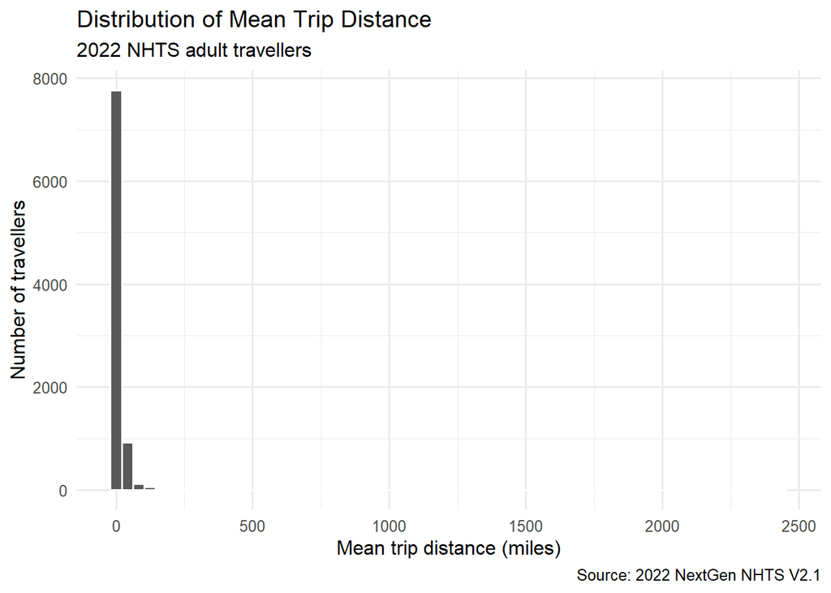

```r
# ==================================================
# Step 20.1 - Histogram of the full outcome distribution
# ==================================================
# ggplot() declares the dataset; aes() maps the outcome to the horizontal axis.
# geom_histogram(bins = 60) builds a frequency histogram across 60 bins.
# A long right tail can compress most observations near zero in a full-scale plot.
# print() displays the stored plot in both interactive and knitted sessions.

# Save the plot object for on-screen review and later PNG export.
p_hist_full <- ggplot(
  analysis_data,
  aes(x = mean_trip_miles)
) +
  # Choose the number of bins rather than filtering out outliers.
  geom_histogram(
    bins = 60,
    colour = "white"
  ) +
  labs(
    title = "Distribution of Mean Trip Distance",
    subtitle = "2022 NHTS adult travellers",
    x = "Mean trip distance (miles)",
    y = "Number of travellers",
    caption = "Source: 2022 NextGen NHTS V2.1"
  ) +
  theme_minimal(base_size = 12)
print(p_hist_full)
```

### Step 20.2 - Zoom the histogram to 0-60 miles

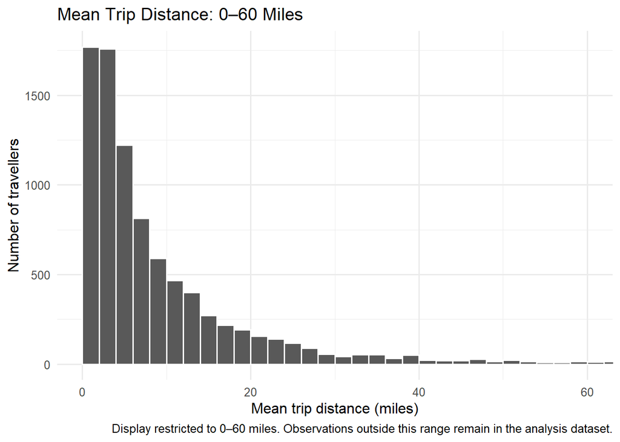

```r
# ==================================================
# Step 20.2 - Zoom the histogram to 0-60 miles
# ==================================================
# binwidth = 2 creates two-mile histogram bins; boundary = 0 anchors the breaks.
# coord_cartesian(xlim = c(0, 60)) changes what is visible, not the dataset.
# The observations beyond 60 miles are still kept for all statistical calculations.

p_hist_zoom <- ggplot(
  analysis_data,
  aes(x = mean_trip_miles)
) +
  geom_histogram(
    binwidth = 2,
    boundary = 0,
    colour = "white"
  ) +
  # Zoom the display only: no observations are deleted from analysis_data.
  coord_cartesian(
    xlim = c(0, 60)
  ) +
  labs(
    title = "Mean Trip Distance: 0–60 Miles",
    x = "Mean trip distance (miles)",
    y = "Number of travellers",
    caption = paste(
      "Display restricted to 0–60 miles.",
      "Observations outside this range",
      "remain in the analysis dataset."
    )
  ) +
  theme_minimal(base_size = 12)
print(p_hist_zoom)
```

### Illustration only - Filtering would create a different subset

The following snippet is retained from the tutorial for comparison only. It is not part of the analytical workflow, so the chunk uses `eval=FALSE`.

```r
# ==================================================
# Illustration only - Filtering would create a different subset
# ==================================================
# This original tutorial example is explanatory and is intentionally NOT executed.
# filter() would exclude rows above 60 miles from the returned dataset.
# It must not replace the main analysis_data just to make a plot look clearer.

# Contrast only: filtering would create a different analysis subset.
analysis_data %>%
  filter(mean_trip_miles <= 60)
```

### Step 20.2 - Count observations beyond the displayed range

```r
# ==================================================
# Step 20.2 - Count observations beyond the displayed range
# ==================================================
# Quantify how many observations fall outside the 0-60-mile display range.
# The percentage can be cited in a caption to document the visible truncation.

analysis_data %>%
  summarise(
    n_above_60 = sum(mean_trip_miles > 60),
    pct_above_60 = 100 * mean(
      mean_trip_miles > 60
    )
  )
```

```
## # A tibble: 1 × 2
##   n_above_60 pct_above_60
##        <int>        <dbl>
## 1        371         4.10
```

### Step 20.3 - Histogram of log(1 + mean trip miles)

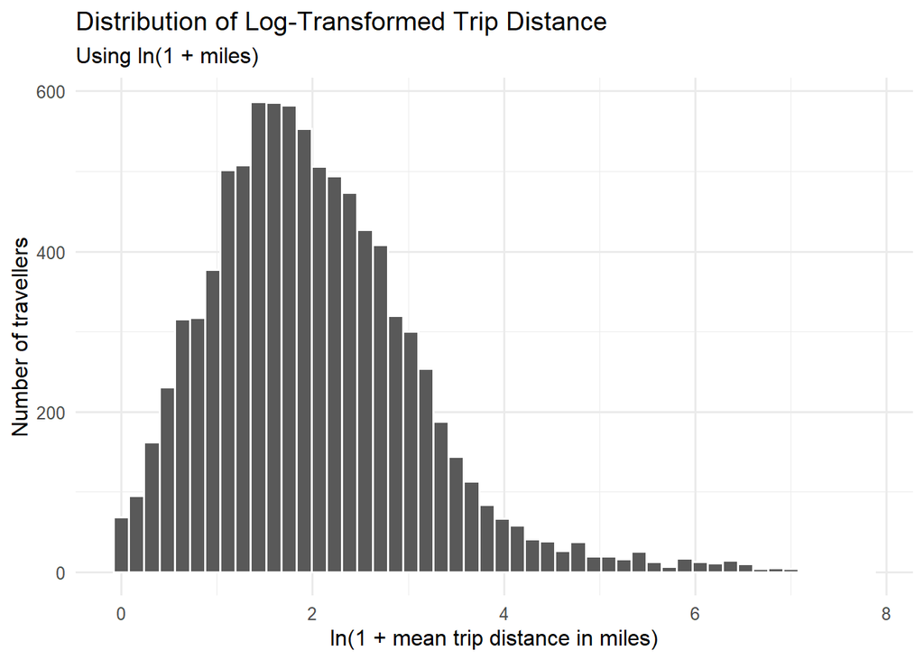

```r
# ==================================================
# Step 20.3 - Histogram of log(1 + mean trip miles)
# ==================================================
# log1p(x) computes ln(1 + x) and is defined for a zero distance.
# The source analysis uses miles, so the transformed unit must be documented.
# This transformation compresses extreme values; it does not establish OLS assumptions.

# Log transform the person-level outcome for exploratory visualisation.
p_hist_log <- ggplot(
  analysis_data,
  aes(x = log1p(mean_trip_miles))
) +
  geom_histogram(
    bins = 50,
    colour = "white"
  ) +
  labs(
    title = "Distribution of Log-Transformed Trip Distance",
    subtitle = "Using ln(1 + miles)",
    x = "ln(1 + mean trip distance in miles)",
    y = "Number of travellers"
  ) +
  theme_minimal(base_size = 12)
print(p_hist_log)
```

### Save the Stage 20 distribution figures

```r
# ==================================================
# Save the Stage 20 distribution figures
# ==================================================
# ggsave() writes high-resolution PNG files for report preparation.
# width and height are measured in inches, and dpi controls raster resolution.
# All outputs go to the figures/ directory located at the project root.

ggsave(
  filename = file.path(figures_dir, "Figure_1a_full_distribution.png"),
  plot = p_hist_full,
  width = 8,
  height = 5,
  dpi = 300
)
ggsave(
  filename = file.path(figures_dir, "Figure_1b_zoomed_distribution.png"),
  plot = p_hist_zoom,
  width = 8,
  height = 5,
  dpi = 300
)
ggsave(
  filename = file.path(figures_dir, "Figure_1c_log_distribution.png"),
  plot = p_hist_log,
  width = 8,
  height = 5,
  dpi = 300
)
```

## Step 21 - Density and trip-distance visualisations

### Step 21 - Define readable population-density axis labels

```r
# ==================================================
# Step 21 - Define readable population-density axis labels
# ==================================================
# Names such as "01" and "02" refer to the categorical codes in density_band.
# Labels display people per square mile and do not alter the source variable.
# The "25,000+" label abbreviates the top category; consult the codebook for bounds.

# Map 01-08 factor codes to human-readable population-density ranges.
density_labels <- c(
  "01" = "0–99",
  "02" = "100–499",
  "03" = "500–999",
  "04" = "1,000–1,999",
  "05" = "2,000–3,999",
  "06" = "4,000–9,999",
  "07" = "10,000–24,999",
  "08" = "25,000+"
)
```

### Step 21.1 - Boxplot of outcome by population density

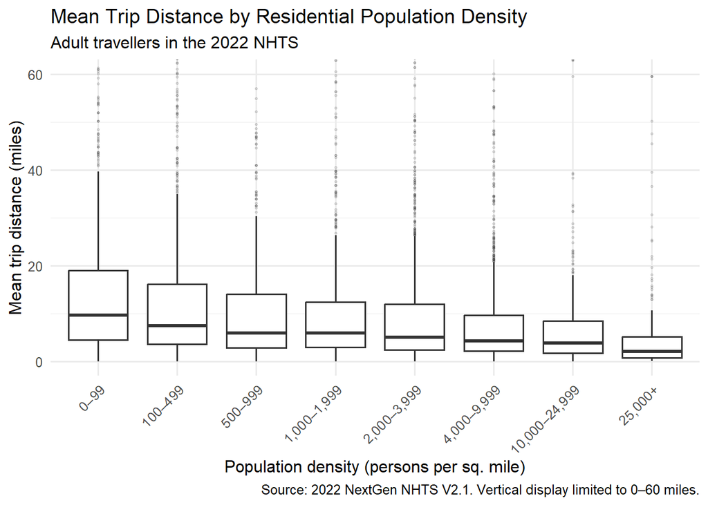

```r
# ==================================================
# Step 21.1 - Boxplot of outcome by population density
# ==================================================
# Each box describes the median and interquartile range of person-level means.
# geom_boxplot() marks potential outliers according to the boxplot rule.
# coord_cartesian() limits only the plotted y-axis to 0-60 miles.
# Overlapping boxes show descriptive overlap, not a statistical significance test.

p_density_box <- ggplot(
  analysis_data,
  aes(
    x = density_band,
    y = mean_trip_miles
  )
) +
  # Box = IQR, central line = median; points beyond whiskers are shown as outliers.
  geom_boxplot(
    outlier.alpha = 0.15,
    outlier.size = 0.6
  ) +
  coord_cartesian(
    ylim = c(0, 60)
  ) +
  scale_x_discrete(
    labels = density_labels
  ) +
  labs(
    title = "Mean Trip Distance by Residential Population Density",
    subtitle = "Adult travellers in the 2022 NHTS",
    x = "Population density (persons per sq. mile)",
    y = "Mean trip distance (miles)",
    caption = paste(
      "Source: 2022 NextGen NHTS V2.1.",
      "Vertical display limited to 0–60 miles."
    )
  ) +
  theme_minimal(base_size = 12) +
  theme(
    axis.text.x = element_text(
      angle = 45,
      hjust = 1
    )
  )
print(p_density_box)
```

### Step 21.2 - Boxplot with a log-transformed outcome

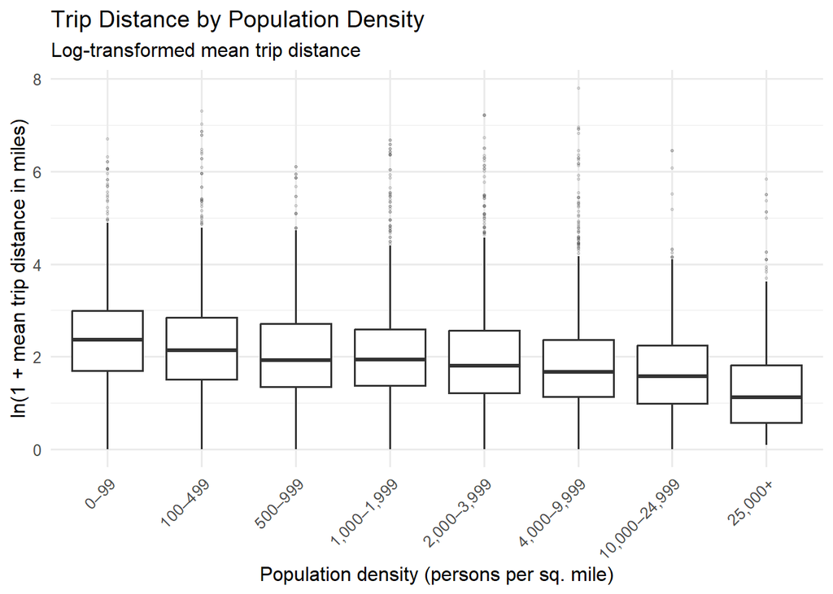

```r
# ==================================================
# Step 21.2 - Boxplot with a log-transformed outcome
# ==================================================
# Plot ln(1 + miles) as an alternative view of long-tailed outcomes.
# The categorical density groups remain unchanged.
# Because units are transformed, this should be explained clearly in figure text.

p_density_log_box <- ggplot(
  analysis_data,
  aes(
    x = density_band,
    y = log1p(mean_trip_miles)
  )
) +
  geom_boxplot(
    outlier.alpha = 0.15,
    outlier.size = 0.6
  ) +
  scale_x_discrete(
    labels = density_labels
  ) +
  labs(
    title = "Trip Distance by Population Density",
    subtitle = "Log-transformed mean trip distance",
    x = "Population density (persons per sq. mile)",
    y = "ln(1 + mean trip distance in miles)"
  ) +
  theme_minimal(base_size = 12) +
  theme(
    axis.text.x = element_text(
      angle = 45,
      hjust = 1
    )
  )
print(p_density_log_box)
```

### Step 21.3 - Compare group means and medians

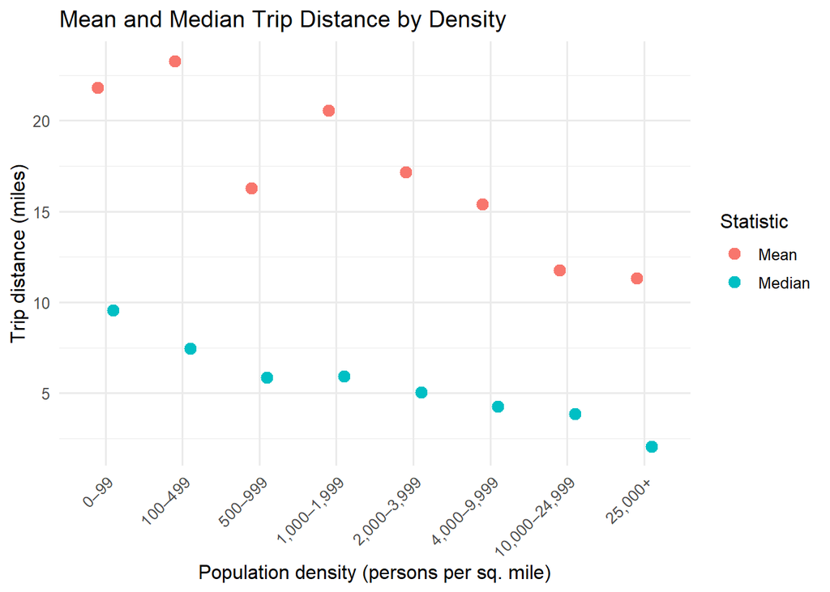

```r
# ==================================================
# Step 21.3 - Compare group means and medians
# ==================================================
# select() extracts the two statistics from the Step 19 summary.
# pivot_longer() prepares the data in long format for a single ggplot call.
# recode() replaces internal column names with readable legend labels.
# position_dodge() separates mean and median points within each density group.

# Reshape group summary statistics into a format ggplot can map to a legend.
density_compare <- density_summary %>%
  select(
    density_band,
    mean_miles,
    median_miles
  ) %>%
  pivot_longer(
    cols = c(mean_miles, median_miles),
    names_to = "statistic",
    values_to = "distance"
  ) %>%
  mutate(
    statistic = recode(
      statistic,
      mean_miles = "Mean",
      median_miles = "Median"
    )
  )
# Compare mean versus median without inferring causal effects.
p_density_compare <- ggplot(
  density_compare,
  aes(
    x = density_band,
    y = distance,
    colour = statistic
  )
) +
  geom_point(
    position = position_dodge(width = 0.4),
    size = 3
  ) +
  scale_x_discrete(
    labels = density_labels
  ) +
  labs(
    title = "Mean and Median Trip Distance by Density",
    x = "Population density (persons per sq. mile)",
    y = "Trip distance (miles)",
    colour = "Statistic"
  ) +
  theme_minimal(base_size = 12) +
  theme(
    axis.text.x = element_text(
      angle = 45,
      hjust = 1
    )
  )
print(p_density_compare)
```

### Save population-density comparison figures

```r
# ==================================================
# Save population-density comparison figures
# ==================================================
# Store all three exploratory plots, even if the final paper presents only one.
# PNG resolution is 300 DPI to support inclusion in a research report.

ggsave(
  file.path(figures_dir, "Figure_2a_density_boxplot.png"),
  plot = p_density_box,
  width = 9,
  height = 5.5,
  dpi = 300
)
ggsave(
  file.path(figures_dir, "Figure_2b_density_log_boxplot.png"),
  plot = p_density_log_box,
  width = 9,
  height = 5.5,
  dpi = 300
)
ggsave(
  file.path(figures_dir, "Figure_2c_density_mean_median.png"),
  plot = p_density_compare,
  width = 9,
  height = 5.5,
  dpi = 300
)
```

## Step 22 - Multivariable exploratory comparisons

### Step 22.1 - Compare density categories by employment status

```r
# ==================================================
# Step 22.1 - Compare density categories by employment status
# ==================================================
# Cross-classify population density and worker status to inspect group profiles.
# Summarise both sample size and distinct household count for context.
# This is descriptive: differences do not imply interactions are significant or causal.

# Cross-classify the sample by both density and employment status.
worker_density <- analysis_data %>%
  group_by(
    density_band,
    worker
  ) %>%
  summarise(
    n = n(),
    households = n_distinct(HOUSEID),
    mean_miles = mean(mean_trip_miles),
    median_miles = median(mean_trip_miles),
    .groups = "drop"
  )
print(worker_density)
```

```
## # A tibble: 16 × 6
##    density_band worker         n households mean_miles median_miles
##    <fct>        <fct>      <int>      <int>      <dbl>        <dbl>
##  1 01           worker       675        494      22.2         10.7
##  2 01           not_worker   464        373      21.2          8.15
##  3 02           worker       782        576      25.2          9.38
##  4 02           not_worker   548        451      20.6          5.48
##  5 03           worker       481        354      17.2          6.82
##  6 03           not_worker   291        231      14.7          4.43
##  7 04           worker       763        565      21.2          7.10
##  8 04           not_worker   509        407      19.6          4.44
##  9 05           worker      1209        902      16.9          5.75
## 10 05           not_worker   707        558      17.6          3.97
## 11 06           worker      1194        871      17.5          5.15
## 12 06           not_worker   726        588      11.9          3.02
## 13 07           worker       329        253      10.5          4.24
## 14 07           not_worker   109         93      15.7          3.07
## 15 08           worker       186        146      13.2          2.38
## 16 08           not_worker    79         67       6.90         1.79
```

### Step 22.1 - Draw the employment-status comparison plot

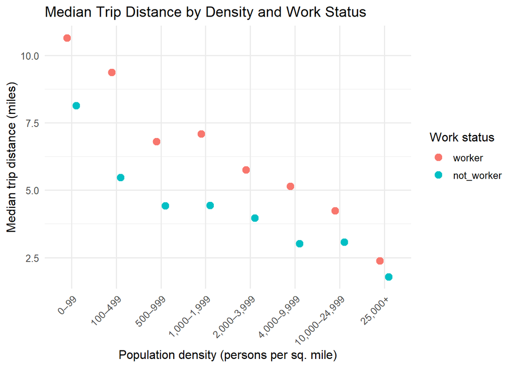

```r
# ==================================================
# Step 22.1 - Draw the employment-status comparison plot
# ==================================================
# Plot median travel distance for workers and non-workers within each density group.
# Colour distinguishes categories; dodge prevents markers from overlapping.
# Sparse groups should be interpreted cautiously before any interaction modelling.

p_worker <- ggplot(
  worker_density,
  aes(
    x = density_band,
    y = median_miles,
    colour = worker
  )
) +
  geom_point(
    position = position_dodge(width = 0.4),
    size = 3
  ) +
  scale_x_discrete(
    labels = density_labels
  ) +
  labs(
    title = "Median Trip Distance by Density and Work Status",
    x = "Population density (persons per sq. mile)",
    y = "Median trip distance (miles)",
    colour = "Work status"
  ) +
  theme_minimal(base_size = 12) +
  theme(
    axis.text.x = element_text(
      angle = 45,
      hjust = 1
    )
  )
print(p_worker)
```

### Step 22.2 - Create density-by-vehicle sample counts

```r
# ==================================================
# Step 22.2 - Create density-by-vehicle sample counts
# ==================================================
# count(density_band, car_group, .drop = FALSE) includes zero-count combinations.
# pivot_wider() turns vehicle classes into columns to produce a cross-tabulation.
# Inspect small cells before considering complex density-by-car interaction terms.

# Retain missing combinations of factor levels as explicit 0-count cells.
car_density_count <- analysis_data %>%
  count(
    density_band,
    car_group,
    .drop = FALSE,
    name = "n"
  )
# Make a wide-format, readable cross-tabulation.
car_density_table <- car_density_count %>%
  pivot_wider(
    names_from = car_group,
    values_from = n,
    values_fill = 0
  )
print(car_density_table)
```

```
## # A tibble: 8 × 4
##   density_band   `0`   `1`  `2+`
##   <fct>        <int> <int> <int>
## 1 01               6   189   944
## 2 02              16   241  1073
## 3 03              10   168   594
## 4 04              18   259   995
## 5 05              40   436  1440
## 6 06              76   573  1271
## 7 07              27   208   203
## 8 08              93   124    48
```

Small cross-classification cells suggest caution before fitting interactions in later regression stages.

### Step 22.2 - Heatmap of sample sizes for interaction cells

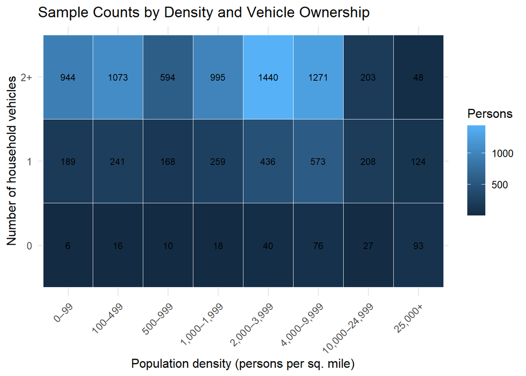

```r
# ==================================================
# Step 22.2 - Heatmap of sample sizes for interaction cells
# ==================================================
# geom_tile() colours each density-by-vehicle cell according to respondent count.
# geom_text(aes(label = n)) prints the counts inside the tiles.
# Low counts can make interaction effects unstable even with a large total sample.

p_car_heatmap <- ggplot(
  car_density_count,
  aes(
    x = density_band,
    y = car_group,
    fill = n
  )
) +
  # Draw one rectangle per density-by-vehicle cell.
  geom_tile(
    colour = "white"
  ) +
  geom_text(
    aes(label = n),
    size = 3
  ) +
  scale_x_discrete(
    labels = density_labels
  ) +
  labs(
    title = "Sample Counts by Density and Vehicle Ownership",
    x = "Population density (persons per sq. mile)",
    y = "Number of household vehicles",
    fill = "Persons"
  ) +
  theme_minimal(base_size = 12) +
  theme(
    axis.text.x = element_text(
      angle = 45,
      hjust = 1
    )
  )
print(p_car_heatmap)
```

### Step 22.3 - Weekday-specific trip distance summaries

```r
# ==================================================
# Step 22.3 - Weekday-specific trip distance summaries
# ==================================================
# group_by(day_of_week) creates separate summaries for each survey weekday.
# Median helps represent typical distances in a right-skewed distribution.

weekday_summary <- analysis_data %>%
  group_by(day_of_week) %>%
  summarise(
    n = n(),
    mean_miles = mean(mean_trip_miles),
    median_miles = median(mean_trip_miles),
    .groups = "drop"
  )
print(weekday_summary)
```

```
## # A tibble: 7 × 4
##   day_of_week     n mean_miles median_miles
##   <fct>       <int>      <dbl>        <dbl>
## 1 Sunday       1434       26.0         5.27
## 2 Monday       1699       18.1         5.74
## 3 Tuesday      1294       13.9         5.58
## 4 Wednesday    1171       14.4         5.15
## 5 Thursday     1220       12.9         5.68
## 6 Friday       1256       19.3         5.76
## 7 Saturday      978       22.8         5.69
```

### Step 22.3 - Bar chart of weekday medians

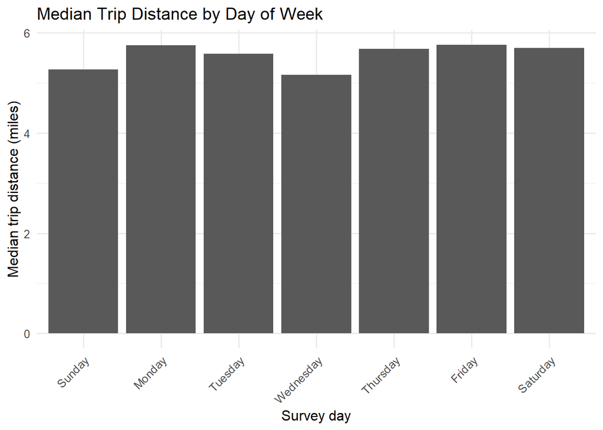

```r
# ==================================================
# Step 22.3 - Bar chart of weekday medians
# ==================================================
# geom_col() draws bars from precomputed medians (rather than counting rows).
# Use the plot to assess whether weekday controls are substantively relevant.

p_weekday <- ggplot(
  weekday_summary,
  aes(
    x = day_of_week,
    y = median_miles
  )
) +
  geom_col() +
  labs(
    title = "Median Trip Distance by Day of Week",
    x = "Survey day",
    y = "Median trip distance (miles)"
  ) +
  theme_minimal(base_size = 12) +
  theme(
    axis.text.x = element_text(
      angle = 45,
      hjust = 1
    )
  )
print(p_weekday)
```

### Save work-status, vehicle-ownership and weekday figures

```r
# ==================================================
# Save work-status, vehicle-ownership and weekday figures
# ==================================================
# The filenames match the tutorial examples so outputs are easy to locate.
# The three plot objects must exist from Steps 22.1 to 22.3 before saving.

ggsave(
  file.path(figures_dir, "Figure_3_work_status.png"),
  plot = p_worker,
  width = 9,
  height = 5.5,
  dpi = 300
)
ggsave(
  file.path(figures_dir, "Figure_4_vehicle_heatmap.png"),
  plot = p_car_heatmap,
  width = 9,
  height = 5.5,
  dpi = 300
)
ggsave(
  file.path(figures_dir, "Figure_5_weekday.png"),
  plot = p_weekday,
  width = 8,
  height = 5,
  dpi = 300
)
```

## Export the summary tables and inspect saved files

### Export the Stage 3 summary tables as CSV

```r
# ==================================================
# Export the Stage 3 summary tables as CSV
# ==================================================
# write_csv() exports data frames for inspection, reporting, and later reuse.
# The tables contain derived summaries; the person-level input RDS is unchanged.
# All paths resolve under the project-root tables/ directory.

# Export the computed table into the project-root tables directory.
write_csv(
  y_summary,
  file.path(tables_dir, "01_dependent_variable_summary.csv")
)
write_csv(
  continuous_summary,
  file.path(tables_dir, "02_continuous_summary.csv")
)
write_csv(
  worker_summary,
  file.path(tables_dir, "03_worker_summary.csv")
)
write_csv(
  car_summary,
  file.path(tables_dir, "04_car_summary.csv")
)
write_csv(
  density_summary,
  file.path(tables_dir, "05_density_summary.csv")
)
write_csv(
  zero_by_density,
  file.path(tables_dir, "06_zero_distance_by_density.csv")
)
write_csv(
  worker_density,
  file.path(tables_dir, "07_density_by_work_status.csv")
)
write_csv(
  car_density_count,
  file.path(tables_dir, "08_density_by_vehicle_count.csv")
)
write_csv(
  weekday_summary,
  file.path(tables_dir, "09_weekday_summary.csv")
)
```

### Inspect the generated table and figure filenames

```r
# ==================================================
# Inspect the generated table and figure filenames
# ==================================================
# list.files() verifies what was written to the two output directories.
# Run this only after the previous export chunks have completed.

list.files(tables_dir)
```

```
##  [1] "01_dependent_variable_summary.csv" "02_continuous_summary.csv"
##  [3] "03_worker_summary.csv"             "04_car_summary.csv"
##  [5] "05_density_summary.csv"            "06_zero_distance_by_density.csv"
##  [7] "07_density_by_work_status.csv"     "08_density_by_vehicle_count.csv"
##  [9] "09_weekday_summary.csv"            "sample_flow.csv"
```

```r
list.files(figures_dir)
```

```
## [1] "Figure_1a_full_distribution.png"   "Figure_1b_zoomed_distribution.png"
## [3] "Figure_1c_log_distribution.png"    "Figure_2a_density_boxplot.png"
## [5] "Figure_2b_density_log_boxplot.png" "Figure_2c_density_mean_median.png"
## [7] "Figure_3_work_status.png"          "Figure_4_vehicle_heatmap.png"
## [9] "Figure_5_weekday.png"
```

## Interpretation reminders

- Compare **means and medians**: strong differences may indicate a long right tail and sensitivity to extreme journeys.
- Treat density codes **01–08 as categories**, not equally spaced numeric measurements of population density.
- Keep the full analytical sample for inferential work. Display-only axis limits do not justify dropping long-distance observations.
- Check sparse density-by-vehicle cells before considering interaction terms; also inspect the number of distinct households.
- Report whether descriptive results are weighted or unweighted. A weighted mean alone does not supply complex-survey uncertainty estimates.